# Final_Project

Haw-Jan Hwang

October 14, 2019

# Import Data

There are total 20 columns and 3338 rows and most of the features are numeric data

```r
df = read.csv('SkillCraft.csv')
str(df)
```

```
## 'data.frame':    3338 obs. of  20 variables:
##  $ GameID              : int  52 55 56 57 58 60 61 72 77 81 ...
##  $ LeagueIndex         : int  5 5 4 3 3 2 1 7 4 4 ...
##  $ Age                 : int  27 23 30 19 32 27 21 17 20 18 ...
##  $ HoursPerWeek        : int  10 10 10 20 10 6 8 42 14 24 ...
##  $ TotalHours          : int  3000 5000 200 400 500 70 240 10000 2708 800 ...
##  $ APM                 : num  144 129 70 108 123 ...
##  $ SelectByHotkeys     : num  0.00352 0.0033 0.0011 0.00103 0.00114 ...
##  $ AssignToHotkeys     : num  0.00022 0.000259 0.000336 0.000213 0.000327 ...
##  $ UniqueHotkeys       : int  7 4 4 1 2 2 6 6 2 8 ...
##  $ MinimapAttacks      : num  1.10e-04 2.94e-04 2.94e-04 5.33e-05 0.00 ...
##  $ MinimapRightClicks  : num  0.000392 0.000432 0.000461 0.000543 0.001329 ...
##  $ NumberOfPACs        : num  0.00485 0.00431 0.00293 0.00378 0.00237 ...
##  $ GapBetweenPACs      : num  32.7 32.9 44.6 29.2 22.7 ...
##  $ ActionLatency       : num  40.9 42.3 75.4 53.7 62.1 ...
##  $ ActionsInPAC        : num  4.75 4.84 4.04 4.92 9.37 ...
##  $ TotalMapExplored    : int  28 22 22 19 15 16 15 45 29 27 ...
##  $ WorkersMade         : num  0.001397 0.001193 0.000745 0.000426 0.001174 ...
##  $ UniqueUnitsMade     : int  6 5 6 7 4 6 5 9 7 6 ...
##  $ ComplexUnitsMade    : num  0 0 0 0 0 ...
##  $ ComplexAbilitiesUsed: num  0.00 2.08e-04 1.89e-04 3.84e-04 1.93e-05 ...
```

# Attribute Information

1. GameID: Unique ID number for each game (integer)
2. LeagueIndex: Bronze, Silver, Gold, Platinum, Diamond, Master, GrandMaster, and Professional leagues coded 1-7 (Ordinal)
3. Age: Age of each player (integer)
4. HoursPerWeek: Reported hours spent playing per week (integer)
5. TotalHours: Reported total hours spent playing (integer)
6. APM: Action per minute (continuous)
7. SelectByHotkeys: Number of unit or building selections made using hotkeys per timestamp (continuous)
8. AssignToHotkeys: Number of units or buildings assigned to hotkeys per timestamp (continuous)
9. UniqueHotkeys: Number of unique hotkeys used per timestamp (continuous)
10. MinimapAttacks: Number of attack actions on minimap per timestamp (continuous)
11. MinimapRightClicks: number of right-clicks on minimap per timestamp (continuous)
12. NumberOfPACs: Number of PACs per timestamp (continuous) (A PAC is when one changes screen location and performs 1+ actions before changing screen location again to repeat.)
13. GapBetweenPACs: Mean duration in milliseconds between PACs (continuous)
14. ActionLatency: Mean latency from the onset of a PACs to their first action in milliseconds (continuous)
15. ActionsInPAC: Mean number of actions within each PAC (continuous)
16. TotalMapExplored: The number of 24x24 game coordinate grids viewed by the player per timestamp (continuous)
17. WorkersMade: Number of SCVs, drones, and probes trained per timestamp (continuous)
18. UniqueUnitsMade: Unique unites made per timestamp (continuous)
19. ComplexUnitsMade: Number of ghosts, infestors, and high templars trained per timestamp (continuous)
20. ComplexAbilitiesUsed: Abilities requiring specific targeting instructions used per timestamp (continuous)

# Data Summary

From the code below, we can see the preliminary summary of all the features.

```r
summary(df)
```

```
##      GameID      LeagueIndex         Age         HoursPerWeek
##  Min.   :  52   Min.   :1.000   Min.   :16.00   Min.   :  0.00
##  1st Qu.:2423   1st Qu.:3.000   1st Qu.:19.00   1st Qu.:  8.00
##  Median :4788   Median :4.000   Median :21.00   Median : 12.00
##  Mean   :4720   Mean   :4.121   Mean   :21.65   Mean   : 15.91
##  3rd Qu.:6995   3rd Qu.:5.000   3rd Qu.:24.00   3rd Qu.: 20.00
##  Max.   :9271   Max.   :7.000   Max.   :44.00   Max.   :168.00
##    TotalHours             APM         SelectByHotkeys
##  Min.   :      3.0   Min.   : 22.06   Min.   :0.000000
##  1st Qu.:    300.0   1st Qu.: 79.23   1st Qu.:0.001245
##  Median :    500.0   Median :107.07   Median :0.002445
##  Mean   :    960.4   Mean   :114.58   Mean   :0.004023
##  3rd Qu.:    800.0   3rd Qu.:140.16   3rd Qu.:0.004945
##  Max.   :1000000.0   Max.   :389.83   Max.   :0.043088
##  AssignToHotkeys     UniqueHotkeys    MinimapAttacks
##  Min.   :0.0000000   Min.   : 0.000   Min.   :0.000e+00
##  1st Qu.:0.0002017   1st Qu.: 3.000   1st Qu.:0.000e+00
##  Median :0.0003487   Median : 4.000   Median :3.864e-05
##  Mean   :0.0003641   Mean   : 4.316   Mean   :9.378e-05
##  3rd Qu.:0.0004929   3rd Qu.: 6.000   3rd Qu.:1.134e-04
##  Max.   :0.0016483   Max.   :10.000   Max.   :3.019e-03
##  MinimapRightClicks   NumberOfPACs      GapBetweenPACs    ActionLatency
##  Min.   :0.0000000   Min.   :0.000679   Min.   :  6.667   Min.   : 24.63
##  1st Qu.:0.0001388   1st Qu.:0.002743   1st Qu.: 29.327   1st Qu.: 50.89
##  Median :0.0002784   Median :0.003376   Median : 37.059   Median : 61.30
##  Mean   :0.0003802   Mean   :0.003433   Mean   : 40.714   Mean   : 64.21
##  3rd Qu.:0.0005076   3rd Qu.:0.004003   3rd Qu.: 48.510   3rd Qu.: 74.03
##  Max.   :0.0036877   Max.   :0.007971   Max.   :237.143   Max.   :176.37
##   ActionsInPAC    TotalMapExplored  WorkersMade        UniqueUnitsMade
##  Min.   : 2.039   Min.   : 5.00    Min.   :7.698e-05   Min.   : 2.000
##  1st Qu.: 4.262   1st Qu.:17.00    1st Qu.:6.818e-04   1st Qu.: 5.000
##  Median : 5.087   Median :22.00    Median :9.042e-04   Median : 6.000
##  Mean   : 5.267   Mean   :22.12    Mean   :1.031e-03   Mean   : 6.541
##  3rd Qu.: 6.027   3rd Qu.:27.00    3rd Qu.:1.258e-03   3rd Qu.: 8.000
##  Max.   :18.558   Max.   :58.00    Max.   :5.149e-03   Max.   :13.000
##  ComplexUnitsMade    ComplexAbilitiesUsed
##  Min.   :0.000e+00   Min.   :0.000e+00
##  1st Qu.:0.000e+00   1st Qu.:0.000e+00
##  Median :0.000e+00   Median :2.043e-05
##  Mean   :5.998e-05   Mean   :1.419e-04
##  3rd Qu.:8.742e-05   3rd Qu.:1.823e-04
##  Max.   :9.023e-04   Max.   :3.084e-03
```

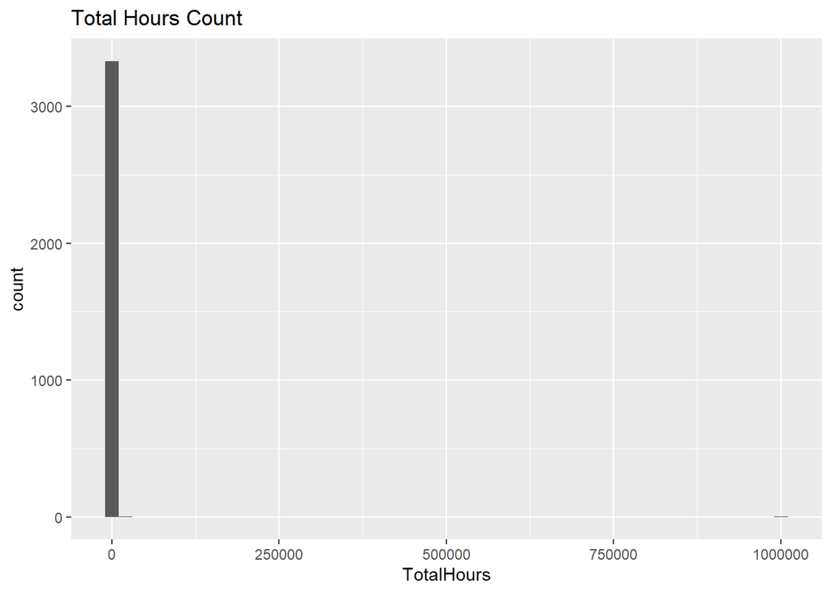

```r
total_hours = ggplot(data=df,aes(x=TotalHours)) + ggtitle('Total Hours Count') +geom_histogram(bins=50)
print(total_hours)
```

# Data Cleaning I remove the outlier and the GameID feature.

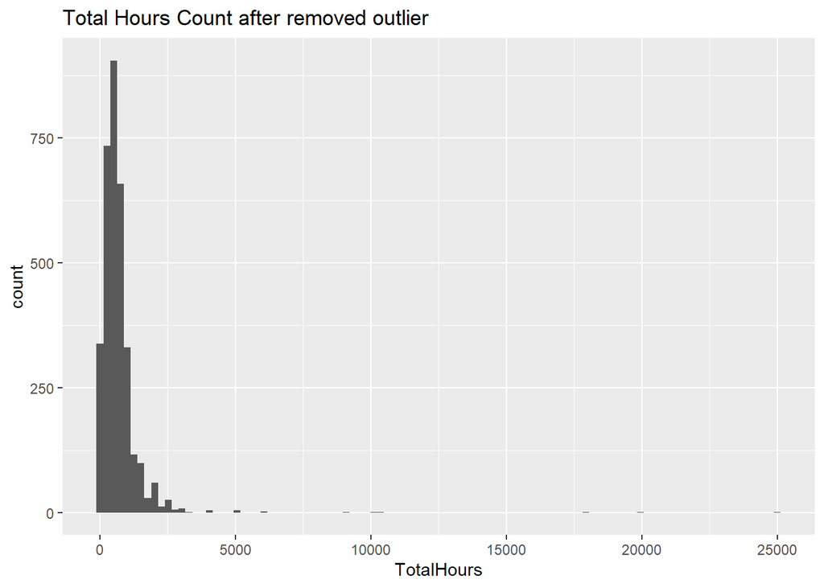

```r
df = df[,-1]
df = df[df$TotalHours!=1000000,]
new_total_hours = ggplot(data=df,aes(x=TotalHours)) + ggtitle('Total Hours Count after removed outlier') + geom_histogram(bins=100)
print(new_total_hours)
```

Transform The LeagueName feature into Categorical variable

```r
league = function(x){
    if (x==1) {return('Bronze')}
    else if (x==2) {return('Silver')}
    else if (x==3) {return('Gold')}
    else if (x==4) {return('Platinum')}
    else if (x==5) {return('Diamond')}
    else if (x==6) {return('Master')}
    else {return('Grand Master')}
}
df$LeagueName = sapply(df$LeagueIndex,league)
```

```r
df <- na.omit(df)
```

# Feature Group 1

```r
group1<-df %>% group_by(LeagueIndex) %>% select(Age, HoursPerWeek, TotalHours, APM, ActionLatency, GapBetweenPACs, ActionsInPAC) %>% summarise(avg_age = mean(Age), avg_Hours = mean(HoursPerWeek), avgTotalHours = mean(TotalHours), avg_APM = mean(APM), avg_actionLatency = mean(ActionLatency), avg_GapPacs= mean(GapBetweenPACs), avg_actionPac = mean(ActionsInPAC))
```

# Feature Group 2

```r
group2<-df %>% group_by(LeagueIndex) %>% select(SelectByHotkeys,AssignToHotkeys,UniqueHotkeys,MinimapAttacks, MinimapRightClicks,NumberOfPACs, TotalMapExplored, WorkersMade, UniqueUnitsMade, ComplexUnitsMade, ComplexAbilitiesUsed) %>% summarise(avg_selectHotKeys = mean(SelectByHotkeys), avg_assignHotKeys = mean(AssignToHotkeys), avg_minimapAttacks = mean(MinimapAttacks),avg_minimapRightClicks = mean(MinimapRightClicks), avg_numPacs = mean(NumberOfPACs), avg_worker = mean(WorkersMade), avg_complexUnit = mean(ComplexUnitsMade), avg_complexAbilities = mean(ComplexAbilitiesUsed))
maxGr1<-c(50,50,1750,200,100,100,10)
minGr1<-rep(0,7)
maxGr2<-c(.01,.01,.01,.01,.01,.01,.01,.01)
minGr2<-rep(0,11)
```

# Grand Master

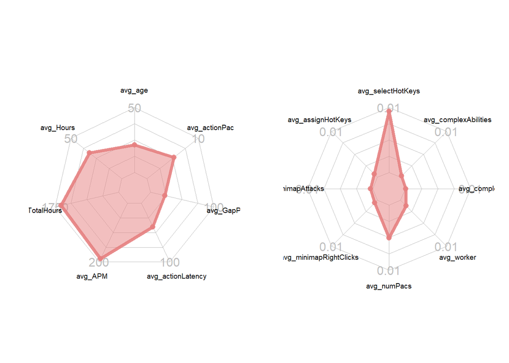

```r
gr1GML<-rbind(maxGr1,minGr1,group1[7,2:8])
gr2GML<-rbind(maxGr2,minGr2,group2[7,2:9])

op <- par(mar=c(1, 2, 2, 1),mfrow=c(1, 2))
radarchart( gr1GML  , axistype=2 ,
    #custom polygon
     pcol=rgb(0.9,0.5,0.5,0.9) , pfcol=rgb(0.9,0.5,0.5,0.5) , plwd=4 ,
     #custom the grid
    cglcol="grey", cglty=1, axislabcol="grey", caxislabels=seq(0,2000,5), cglwd=0.8,
    #custom labels
     vlcex=0.6
     )
radarchart( gr2GML  , axistype=2 ,
    #custom polygon
     pcol=rgb(0.9,0.5,0.5,0.9) , pfcol=rgb(0.9,0.5,0.5,0.5) , plwd=4 ,
     #custom the grid
    cglcol="grey", cglty=1, axislabcol="grey", caxislabels=seq(0,.1,5), cglwd=0.8,
    #custom labels
     vlcex=0.6
     )
```

```r
par(op)
```